# Les tests d’hypothèses

Jeudi

## Rappels

- Hypothèse nulle \(H_0\), c’est l’hypothèse du *statu quo*
- Hypothèse alternative \(H_1\), c’est la situation intéressante ! (signal)
- \(\alpha\) : risque de première espèce, rejeter \(H_0\) lorsqu’elle est vraie (“erreur de détection”)
- \(\beta\) : risque de deuxième espèce, ne pas rejeter \(H_0\) alors que \(H_1\) est vraie (“rater un signal”)
- Puissance : \(1 - \beta\)

| Décision / Verité | Non rejet de \(H_0\) | Rejet \(H_0\) |
| --- | --- | --- |
| \(H_0\) | Confiance | Erreur de 1ère esp. |
| \(H_1\) | Erreur de 2ème esp. | Puissance |

## Expérience de Chastaing (1958)

Keewee ou Koowoo ?

[figure not shown]

## Les résultats

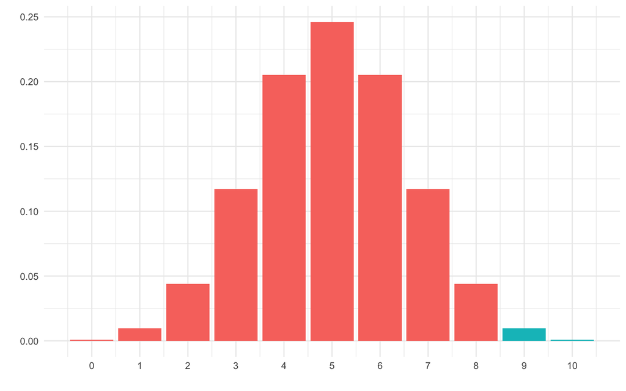

## Rappel 1 : variable aléatoire du \(\chi^2\)

Une variable suivant une loi du khi-deux à \(k\) degrés de liberté (\(\chi^2(k)\)) est la somme des carrés de \(k\) variable normales indépendantes :

\[ \sum_{i = 1}^k Z_i^2 \sim \chi^2(k) \]

Remarques :

- parfois on note une telle variable \(X^2\)
- en pratique, ces “carrés” sont souvent des “variances”

## Rappel 2 : variable aléatoire de Student

Une variable obtenue en divisant un variable normale par la racine carrée d’une variable du khi-deux (indépendante de la première) elle-même normalisée par son dégré de liberté \(d\) suit une loi de Student à \(d\) degrés de liberté :

\[ \frac{Z}{\sqrt{\displaystyle \frac{1}{d} X}} \sim T(d) \]

En pratique : \[ \frac{\text{moyenne}}{\displaystyle \frac{1}{\sqrt{\text{taille}} } \text{ écart-type}} \sim T(\text{taille} - 1) \]

## Rappel 3 : variable aléatoire de Fisher

Le ratio de deux variables indépendantes du khi-deux à \(d_1\) et \(d_2\) degrés de liberté est une variable aléatoire de Fisher à \(d_1\) et \(d_2\) degrés de liberté :

\[ \displaystyle \frac{X^2_1}{X^2_2} \sim F(d_1, d_2) \]

En pratique : des ratios de variance !

## Intermède : Création d’un exemple

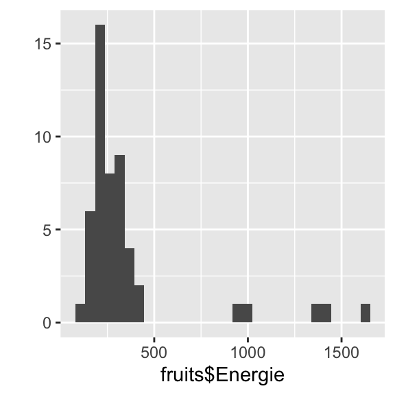

```r
qplot(fruits$Energie)
```

```r
energiequal <- cut(fruits$Energie,
                c(0, 250, 2000))
```

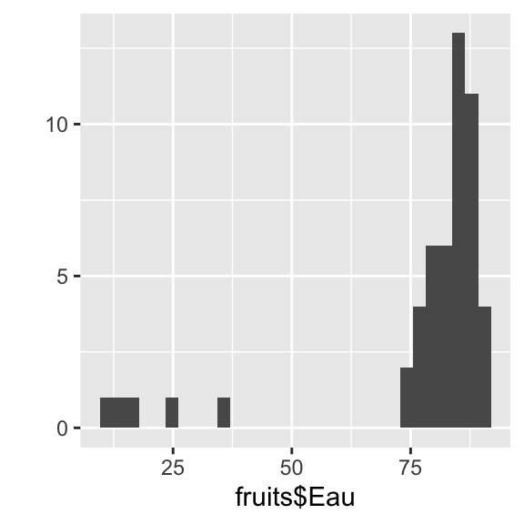

```r
qplot(fruits$Eau)
```

```r
eauqual <- cut(fruits$Eau,
               c(0, 85, 100))
```

## Table de contingence

Une table de contingence, ou table de comptage, est un tableau croisé (de comptage) entre deux variables qualitatives ou plus.

```r
(tab <- table(energiequal, eauqual))
```

```
#>              eauqual
#> energiequal   (0,85] (85,100]
#>   (0,250]          3       23
#>   (250,2e+03]     25        0
```

On peut aussi calculer les proportions

```r
prop.table(tab)
```

```
#>              eauqual
#> energiequal       (0,85]   (85,100]
#>   (0,250]     0.05882353 0.45098039
#>   (250,2e+03] 0.49019608 0.00000000
```

## Profils lignes et profils colonnes

Proportions conditionnellement aux lignes :

```r
prop.table(tab, margin = 1)
```

```
#>              eauqual
#> energiequal      (0,85]  (85,100]
#>   (0,250]     0.1153846 0.8846154
#>   (250,2e+03] 1.0000000 0.0000000
```

Proportions conditionnellement aux colonnes :

```r
prop.table(tab, margin = 2)
```

```
#>              eauqual
#> energiequal      (0,85]  (85,100]
#>   (0,250]     0.1071429 1.0000000
#>   (250,2e+03] 0.8928571 0.0000000
```

## Comparer des proportions

Avec la fonction `prop.test` :

```r
prop.test(table(energiequal, eauqual))
```

```
#>
#>  2-sample test for equality of proportions with continuity
#>  correction
#>
#> data:  table(energiequal, eauqual)
#> X-squared = 36.788, df = 1, p-value = 1.317e-09
#> alternative hypothesis: two.sided
#> 95 percent confidence interval:
#>  -1.0000000 -0.7225806
#> sample estimates:
#>    prop 1    prop 2
#> 0.1153846 1.0000000
```

Attention, le test des proportions a besoin de données de comptage, pour lui : \[ \frac{2}{4} \neq \frac{50}{100} \]

## La fonction `prop.test`

- Accepte des tables de contingences,
- Ou bien deux vecteurs : `x` pour les “succès”, `n` pour le nombre total,
- Éventuellement un vecteur de proportions de référence `p`

Un des exemples de la fonction (cf. `?prop.test`) :

```r
smokers  <- c( 83, 90, 129, 70 )
patients <- c( 86, 93, 136, 82 )
prop.test(smokers, patients)
```

```
#>
#>  4-sample test for equality of proportions without
#>  continuity correction
#>
#> data:  smokers out of patients
#> X-squared = 12.6, df = 3, p-value = 0.005585
#> alternative hypothesis: two.sided
#> sample estimates:
#>    prop 1    prop 2    prop 3    prop 4
#> 0.9651163 0.9677419 0.9485294 0.8536585
```

## Test du “khi-deux”

Avec la fonction `chisq.test` :

```r
chisq.test(energiequal, eauqual)
```

```
#>
#>  Pearson's Chi-squared test with Yates' continuity
#>  correction
#>
#> data:  energiequal and eauqual
#> X-squared = 36.788, df = 1, p-value = 1.317e-09
```

## La fonction `chisq.test`

- Accepte deux variables qualitatives,
- Ou une table de contingence

Un des exemples de la fonction (cf. `?chisq.test`) :

```r
M <- as.table(rbind(c(762, 327, 468), c(484, 239, 477)))
dimnames(M) <- list(gender = c("F", "M"),
                    party = c("Democrat","Independent", "Republican"))
(Xsq <- chisq.test(M))  # Prints test summary
```

```
#>
#>  Pearson's Chi-squared test
#>
#> data:  M
#> X-squared = 30.07, df = 2, p-value = 2.954e-07
```

```r
Xsq$expected   # expected counts under the null
```

```
#>       party
#> gender Democrat Independent Republican
#>      F 703.6714    319.6453   533.6834
#>      M 542.3286    246.3547   411.3166
```

## La statistique du test du \(\chi^2\)

Elle compare les fréquences observées aux fréquences attendues. Les fréquences attendues sont calculées à partir des fréquences marginales sous hypothèse d’indépendance.

\[ X^2 = \displaystyle \sum \frac{\left(n_{ij} - \displaystyle \frac{n_{i\cdot} n_{\cdot j}}{n} \right)^2}{\displaystyle \frac{n_{i\cdot} n_{\cdot j}}{n}}, \] avec \(n_{ij}\) l’effectif observé, \(n_{i\cdot}\) l’effectif marginal ligne, \(n_{\cdot j}\) l’effectif marginal colonne et \(n\) l’effectif total.

Rappel : quand \(A\) et \(B\) son indépendants, \(P(A\cap B) = P(A)P(B)\).

## Test exact de Fisher

Avec la fonction `fisher.test` :

```r
fisher.test(energiequal, eauqual)
```

```
#>
#>  Fisher's Exact Test for Count Data
#>
#> data:  energiequal and eauqual
#> p-value = 1.474e-11
#> alternative hypothesis: true odds ratio is not equal to 1
#> 95 percent confidence interval:
#>  0.00000000 0.03850145
#> sample estimates:
#> odds ratio
#>          0
```

## La fonction `fisher.test`

- Accepte deux variables qualitatives,
- Ou une table de contingence.

Un des exemples de la fonction (cf. `?fisher.test`) :

```r
Convictions <- matrix(
  c(2, 10, 15, 3),
  nrow = 2,
  dimnames = list(
    c("Dizygotic", "Monozygotic"),
    c("Convicted", "Not convicted")))
fisher.test(Convictions, alternative = "less")
```

```
#>
#>  Fisher's Exact Test for Count Data
#>
#> data:  Convictions
#> p-value = 0.0004652
#> alternative hypothesis: true odds ratio is less than 1
#> 95 percent confidence interval:
#>  0.0000000 0.2849601
#> sample estimates:
#> odds ratio
#> 0.04693661
```

## Comparer des moyennes

Avec la fonction `t.test` :

```r
t.test(fruits$VitamineC ~ eauqual)
```

```
#>
#>  Welch Two Sample t-test
#>
#> data:  fruits$VitamineC by eauqual
#> t = -1.6272, df = 37.768, p-value = 0.112
#> alternative hypothesis: true difference in means between group (0,85] and group (85,100] is not equal to 0
#> 95 percent confidence interval:
#>  -21.202176   2.308077
#> sample estimates:
#>   mean in group (0,85] mean in group (85,100]
#>               10.82643               20.27348
```

## Les formules

Les formules permettent à l’utilisateur de décrire un modèle : \[ Y = X_1 + X_2 + X_3 + X_2*X_3 + X_3*X_4 \] deviendra

```
  y ~ x1 + x2 * x3 + x3:x4
```

Repérez le tilde sur votre clavier, il est très important en R !

Exemple :

```
  y ~ x + age + sex + SCL:disease
```

## La fonction `t.test`

- Accepte une formule,
- Ou bien deux vecteurs contenant respectivement les deux groupes de valeurs à comparer,
- L’argument `paired = TRUE` pour des données appariées,
- Ou bien un seul vecteur (pour un test sur une moyenne),

Un des exemples de la fonction (cf. `?t.test`) :

```r
t.test(extra ~ group, data = sleep)
```

```
#>
#>  Welch Two Sample t-test
#>
#> data:  extra by group
#> t = -1.8608, df = 17.776, p-value = 0.07939
#> alternative hypothesis: true difference in means between group 1 and group 2 is not equal to 0
#> 95 percent confidence interval:
#>  -3.3654832  0.2054832
#> sample estimates:
#> mean in group 1 mean in group 2
#>            0.75            2.33
```

## Equivalent non-paramétrique

L’équivalent non-paramétrique du test de Student est le test de Wilcoxon-Mann-Whitney :

```r
wilcox.test(fruits$VitamineC ~ eauqual)
```

[output not shown]

## Remarque sur ces fonctions

L’objet retourné est une liste qui contient les deux éléments les plus intéressants (en général) : `statistic` et `p.value`.

Exemple de récupération de la P-value :

```r
res.ttest <- t.test(fruits$VitamineC ~ eauqual)
pval <- res.ttest$p.value
```

## ANOVA

Faire une ANOVA en R n’est pas une mince affaire !

```r
summary(aov(VitamineC ~ groupe, data = fruits))
```

```
#>             Df Sum Sq Mean Sq F value Pr(>F)
#> groupe       3   4254  1417.9   4.092 0.0116 *
#> Residuals   47  16285   346.5
#> ---
#> Signif. codes:  0 '***' 0.001 '**' 0.01 '*' 0.05 '.' 0.1 ' ' 1
```

Et récupérer la P-value est ridiculement difficile :

```r
res <- summary(aov(VitamineC ~ groupe, data = fruits))
res[[1]]$`Pr(>F)`[1]
```

```
#> [1] 0.01161733
```

## ANOVA non paramétrique

Et la syntaxe est différente pour l’équivalent non-paramétrique : le test de Kruskal-Wallis :

```r
kruskal.test(fruits$VitamineC, fruits$groupe)
```

```
#>
#>  Kruskal-Wallis rank sum test
#>
#> data:  fruits$VitamineC and fruits$groupe
#> Kruskal-Wallis chi-squared = 17.902, df = 3, p-value =
#> 0.0004609
```

Récupérer la p-valeur s’effectue de la même façon que pour un test de Student.

## Corrélation

Avec la fonction `cor.test`. Exemple :

```r
cor.test(fruits$Eau, fruits$Energie)
```

```
#>
#>  Pearson's product-moment correlation
#>
#> data:  fruits$Eau and fruits$Energie
#> t = -49.719, df = 49, p-value < 2.2e-16
#> alternative hypothesis: true correlation is not equal to 0
#> 95 percent confidence interval:
#>  -0.9944420 -0.9828672
#> sample estimates:
#>        cor
#> -0.9902339
```

## La fonction `cor.test`

- Accepte deux vecteurs `x` et `y` de même longueur,
- Permet de tester les trois types de corrélation (Pearson, Sparman et Kendall)

Un des exemples de la fonction (cf. `?cor.test`) :

```r
x <- c(44.4, 45.9, 41.9, 53.3, 44.7, 44.1, 50.7, 45.2, 60.1)
y <- c( 2.6,  3.1,  2.5,  5.0,  3.6,  4.0,  5.2,  2.8,  3.8)

cor.test(x, y, method = "kendall", alternative = "greater")
```

```
#>
#>  Kendall's rank correlation tau
#>
#> data:  x and y
#> T = 26, p-value = 0.05972
#> alternative hypothesis: true tau is greater than 0
#> sample estimates:
#>       tau
#> 0.4444444
```

## Modèles linéaires

Avec la fonction `lm`. Exemple :

```r
res.lm <- lm(Energie ~ Proteines + Sucres + Fibres + Eau,
             data = fruits)
summary(res.lm)
```

```
#>
#> Call:
#> lm(formula = Energie ~ Proteines + Sucres + Fibres + Eau, data = fruits)
#>
#> Residuals:
#>      Min       1Q   Median       3Q      Max
#> -112.599   -8.071   -2.870    2.291  192.788
#>
#> Coefficients:
#>             Estimate Std. Error t value Pr(>|t|)
#> (Intercept) 1377.713    142.894   9.642 1.28e-12 ***
#> Proteines     12.312     13.544   0.909   0.3680
#> Sucres         4.041      1.583   2.553   0.0141 *
#> Fibres       -10.895      4.874  -2.235   0.0303 *
#> Eau          -13.715      1.391  -9.857 6.42e-13 ***
#> ---
#> Signif. codes:  0 '***' 0.001 '**' 0.01 '*' 0.05 '.' 0.1 ' ' 1
#>
#> Residual standard error: 38.78 on 46 degrees of freedom
#> Multiple R-squared:  0.9869, Adjusted R-squared:  0.9858
#> F-statistic: 868.8 on 4 and 46 DF,  p-value: < 2.2e-16
```

## Pour aller plus loin

## Analyse en composantes principales

Les packages

- `FactomineR`
- `factoextra`

Les références :

- le site de François Husson https://husson.github.io/,
- la page sur l’ACP https://husson.github.io/MOOC_AnaDo/ACP.html
- Une référence en anglais par [Hervé Abdi](https://personal.utdallas.edu/~herve/abdi-awPCA2010.pdf)

## Les modèles linéaires à effets mixte

Les packages

- `lme4`
- `lmerTest`
- `multcomp`

Une référence (parmi d’autres) : [Mixed Models with R](https://m-clark.github.io/mixed-models-with-R/random_intercepts.html)